# Cyclistic Bike Share Data

Jerry Dudum

2023-05-30

## Introduction

As a junior data analyst working with the marketing analyst team I am tasked with developing analysis of Cyclistic’s casual and annual rider memberships. From my insights I will design a new marketing strategy to convert casual riders into annual riders. I will complete this task by going through the Ask, Prepare, Process, Analyze, Share and Act phases of data analysis.

## Ask

The ask phase involves addressing pertinent inquiries that will assist in accomplishing the business objective, which in this scenario is to identify disparities in behaviors between casual members and annual members. This information will aid in developing marketing strategies to facilitate the conversion of casual members into annual members. The reason behind this focus is that both the marketing director and the marketing analysis team have concluded that an annual membership is significantly more profitable for the company compared to a casual membership.

To support this business task, the company has provided 12 months worth of collected data. I will utilize Excel and the R programming language to prepare, process, and analyze this data. Subsequently, I will employ Tableau to disseminate the outcomes to the relevant stakeholders.

## Prepare

The prepare phase is where I will be collecting the data and verifying its credibility. Going through the “ROCCC” check (Reliable, Original, Comprehensive, Current and Cited) I can confirm that the 12 months of data provided by Motivate International Inc fits all these conditions. I will now process the data beginning with Excel and moving that data to R.

## Process

The process phase is where I will be cleaning my data by removing any null values, renaming and adding or transforming any data I will find useful in future analysis. I begin by opening all my data within Excel and creating two new columns: “ride_length” and “day_of_week”. I calculate the length of each ride by subtracting the column “started_at” from the column “ended_at” and format this column by time as HH:MM:SS. To calculate the day of the week I employ the WEEKDAY function in Excel. This gives each ride a numerical value 1-7 where 1=Sunday and 7=Saturday. At this point I have transformed the data enough in Excel and there is a lot of data to work with so I will be moving it into R to speed up the rest of the process phase.

First I begin my setting up my environment with all the required libraries and packages I will be utilizing.

```r
install.packages("dplyr")
install.packages("tidyverse")
install.packages("lubridate")
install.packages("readxl")
install.packages("modeest")
install.packages("readr")
library("dplyr")
library("tidyverse")
library("lubridate")
library("readxl")
library("modeest")
library("readr")
```

Once my environment is setup and all necessary libraries are loaded I read all the csv files into variables with their respective month. I will begin with May 2022 as this will be the 12 most recent months.

```r
may <- read.csv("2022_05.csv")
jun <- read.csv("2022_06.csv")
jul <- read.csv("2022_07.csv")
aug <- read.csv("2022_08.csv")
sep <- read.csv("2022_09.csv")
oct <- read.csv("2022_10.csv")
nov <- read.csv("2022_11.csv")
dec <- read.csv("2022_12.csv")
jan <- read.csv("2023_01.csv")
feb <- read.csv("2023_02.csv")
mar <- read.csv("2023_03.csv")
apr <- read.csv("2023_04.csv")
cyclistic_df <- rbind(may, jun, jul, aug, sep, oct, nov, dec, jan, feb, mar, apr)
```

Now we view the dataframe to check every file was read correctly and stored in the dataframe cyclistic_df.

```r
View(cyclistic_df)
str(cyclistic_df)
```

```
## 'data.frame':    5859061 obs. of  15 variables:
##  $ ride_id           : chr  "EC2DE40644C6B0F4" "1C31AD03897EE385" "1542FBEC830415CF" "6FF59852924528F8" ...
##  $ rideable_type     : chr  "classic_bike" "classic_bike" "classic_bike" "classic_bike" ...
##  $ started_at        : chr  "5/23/2022 23:06" "5/11/2022 8:53" "5/26/2022 18:36" "5/10/2022 7:30" ...
##  $ ended_at          : chr  "5/23/2022 23:40" "5/11/2022 9:31" "5/26/2022 18:58" "5/10/2022 7:38" ...
##  $ start_station_name: chr  "Wabash Ave & Grand Ave" "DuSable Lake Shore Dr & Monroe St" "Clinton St & Madison St" "Clinton St & Madison St" ...
##  $ start_station_id  : chr  "TA1307000117" "13300" "TA1305000032" "TA1305000032" ...
##  $ end_station_name  : chr  "Halsted St & Roscoe St" "Field Blvd & South Water St" "Wood St & Milwaukee Ave" "Clark St & Randolph St" ...
##  $ end_station_id    : chr  "TA1309000025" "15534" "13221" "TA1305000030" ...
##  $ start_lat         : num  41.9 41.9 41.9 41.9 41.9 ...
##  $ start_lng         : num  -87.6 -87.6 -87.6 -87.6 -87.6 ...
##  $ end_lat           : num  41.9 41.9 41.9 41.9 41.9 ...
##  $ end_lng           : num  -87.6 -87.6 -87.7 -87.6 -87.7 ...
##  $ member_casual     : chr  "member" "member" "member" "member" ...
##  $ ride_length       : chr  "0:33:21" "0:37:54" "0:21:50" "0:08:42" ...
##  $ day_of_week       : int  2 4 5 3 3 4 6 1 2 4 ...
```

```r
cyclistic_df$start_date <- as.POSIXct(cyclistic_df$started_at, format="%m/%d/%Y", tz="GMT")
cyclistic_df$end_date <- as.POSIXct(cyclistic_df$ended_at, format="%m/%d/%Y", tz="GMT")
cyclistic_df$month <- format(as.Date(cyclistic_df$start_date), "%m")
cyclistic_df$day <- format(as.Date(cyclistic_df$start_date), "%d")
cyclistic_df$year <- format(as.Date(cyclistic_df$start_date), "%Y")
cyclistic_df$day_of_week <- weekdays(cyclistic_df$start_date)
cyclistic_df$ride_length <- as.difftime(cyclistic_df$ride_length, format = "%H:%M:%S", units = "mins")
check_zero <- any(cyclistic_df$ride_length < 0)
cyclistic_df2 <- cyclistic_df[! cyclistic_df$ride_length<0, ]
check_zero <- any(cyclistic_df2$ride_length < 0)
print(check_zero)
```

```
## [1] NA
```

```r
cyclistic_df2$ride_length <- as.numeric(cyclistic_df2$ride_length)
str(cyclistic_df2)
```

```
## 'data.frame':    5859061 obs. of  20 variables:
##  $ ride_id           : chr  "EC2DE40644C6B0F4" "1C31AD03897EE385" "1542FBEC830415CF" "6FF59852924528F8" ...
##  $ rideable_type     : chr  "classic_bike" "classic_bike" "classic_bike" "classic_bike" ...
##  $ started_at        : chr  "5/23/2022 23:06" "5/11/2022 8:53" "5/26/2022 18:36" "5/10/2022 7:30" ...
##  $ ended_at          : chr  "5/23/2022 23:40" "5/11/2022 9:31" "5/26/2022 18:58" "5/10/2022 7:38" ...
##  $ start_station_name: chr  "Wabash Ave & Grand Ave" "DuSable Lake Shore Dr & Monroe St" "Clinton St & Madison St" "Clinton St & Madison St" ...
##  $ start_station_id  : chr  "TA1307000117" "13300" "TA1305000032" "TA1305000032" ...
##  $ end_station_name  : chr  "Halsted St & Roscoe St" "Field Blvd & South Water St" "Wood St & Milwaukee Ave" "Clark St & Randolph St" ...
##  $ end_station_id    : chr  "TA1309000025" "15534" "13221" "TA1305000030" ...
##  $ start_lat         : num  41.9 41.9 41.9 41.9 41.9 ...
##  $ start_lng         : num  -87.6 -87.6 -87.6 -87.6 -87.6 ...
##  $ end_lat           : num  41.9 41.9 41.9 41.9 41.9 ...
##  $ end_lng           : num  -87.6 -87.6 -87.7 -87.6 -87.7 ...
##  $ member_casual     : chr  "member" "member" "member" "member" ...
##  $ ride_length       : num  33.35 37.9 21.83 8.7 5.02 ...
##  $ day_of_week       : chr  "Monday" "Wednesday" "Thursday" "Tuesday" ...
##  $ start_date        : POSIXct, format: "2022-05-23" "2022-05-11" ...
##  $ end_date          : POSIXct, format: "2022-05-23" "2022-05-11" ...
##  $ month             : chr  "05" "05" "05" "05" ...
##  $ day               : chr  "23" "11" "26" "10" ...
##  $ year              : chr  "2022" "2022" "2022" "2022" ...
```

To reduce redundancy and clutter now I will delete the columns we no longer need for the analysis

```r
cyclistic_df2 <- cyclistic_df2 %>%
  select(-c(started_at, ended_at, start_station_id, end_station_id, start_station_name, end_station_name)) %>%
  na.omit(cyclistic_df2)
str(cyclistic_df2)
```

```
## 'data.frame':    5852985 obs. of  14 variables:
##  $ ride_id      : chr  "EC2DE40644C6B0F4" "1C31AD03897EE385" "1542FBEC830415CF" "6FF59852924528F8" ...
##  $ rideable_type: chr  "classic_bike" "classic_bike" "classic_bike" "classic_bike" ...
##  $ start_lat    : num  41.9 41.9 41.9 41.9 41.9 ...
##  $ start_lng    : num  -87.6 -87.6 -87.6 -87.6 -87.6 ...
##  $ end_lat      : num  41.9 41.9 41.9 41.9 41.9 ...
##  $ end_lng      : num  -87.6 -87.6 -87.7 -87.6 -87.7 ...
##  $ member_casual: chr  "member" "member" "member" "member" ...
##  $ ride_length  : num  33.35 37.9 21.83 8.7 5.02 ...
##  $ day_of_week  : chr  "Monday" "Wednesday" "Thursday" "Tuesday" ...
##  $ start_date   : POSIXct, format: "2022-05-23" "2022-05-11" ...
##  $ end_date     : POSIXct, format: "2022-05-23" "2022-05-11" ...
##  $ month        : chr  "05" "05" "05" "05" ...
##  $ day          : chr  "23" "11" "26" "10" ...
##  $ year         : chr  "2022" "2022" "2022" "2022" ...
##  - attr(*, "na.action")= 'omit' Named int [1:6076] 4640 4760 4765 4808 4824 4846 4863 5119 5160 5199 ...
##   ..- attr(*, "names")= chr [1:6076] "4640" "4760" "4765" "4808" ...
```

## Analyze

Now that our data is reformatted and processed the analyze phase can begin. I will be conducting analysis on the cleaned data to understand the behaviors of casual vs member riders to come up with data-driven conclusions to present to stakeholders.

```r
summary(cyclistic_df2$ride_length)
```

```
##     Min.  1st Qu.   Median     Mean  3rd Qu.     Max.
##    0.000    5.650    9.983   15.784   17.883 1439.367
```

```r
aggregate(cyclistic_df2$ride_length ~ cyclistic_df2$member_casual, FUN = mean)
```

```
##   cyclistic_df2$member_casual cyclistic_df2$ride_length
## 1                      casual                  21.13804
## 2                      member                  12.18448
```

```r
aggregate(cyclistic_df2$ride_length ~ cyclistic_df2$member_casual, FUN = median)
```

```
##   cyclistic_df2$member_casual cyclistic_df2$ride_length
## 1                      casual                 12.483333
## 2                      member                  8.666667
```

```r
aggregate(cyclistic_df2$ride_length ~ cyclistic_df2$member_casual, FUN = max)
```

```
##   cyclistic_df2$member_casual cyclistic_df2$ride_length
## 1                      casual                  1439.367
## 2                      member                  1436.333
```

```r
aggregate(cyclistic_df2$ride_length ~ cyclistic_df2$member_casual, FUN = min)
```

```
##   cyclistic_df2$member_casual cyclistic_df2$ride_length
## 1                      casual                         0
## 2                      member                         0
```

This gives us an insight to casual vs members usage however let’s get more specific and utilize the other data we have available to gain more insights.

```r
cyclistic_df2 %>%
  mutate(weekday = wday(start_date, label = TRUE)) %>%
  group_by(member_casual, weekday) %>%
  summarise(number_of_rides = n(), average_ride_length = mean(ride_length)) %>%
  arrange(member_casual, weekday)
```

```
## # A tibble: 14 × 4
## # Groups:   member_casual [2]
##    member_casual weekday number_of_rides average_ride_length
##    <chr>         <ord>             <int>               <dbl>
##  1 casual        Sun              387787                24.3
##  2 casual        Mon              275141                21.4
##  3 casual        Tue              272074                19.0
##  4 casual        Wed              284025                18.2
##  5 casual        Thu              317853                18.9
##  6 casual        Fri              349312                20.2
##  7 casual        Sat              466798                23.7
##  8 member        Sun              401971                13.5
##  9 member        Mon              484467                11.7
## 10 member        Tue              544286                11.6
## 11 member        Wed              556822                11.6
## 12 member        Thu              560770                11.8
## 13 member        Fri              497364                12.0
## 14 member        Sat              454315                13.6
```

## Share

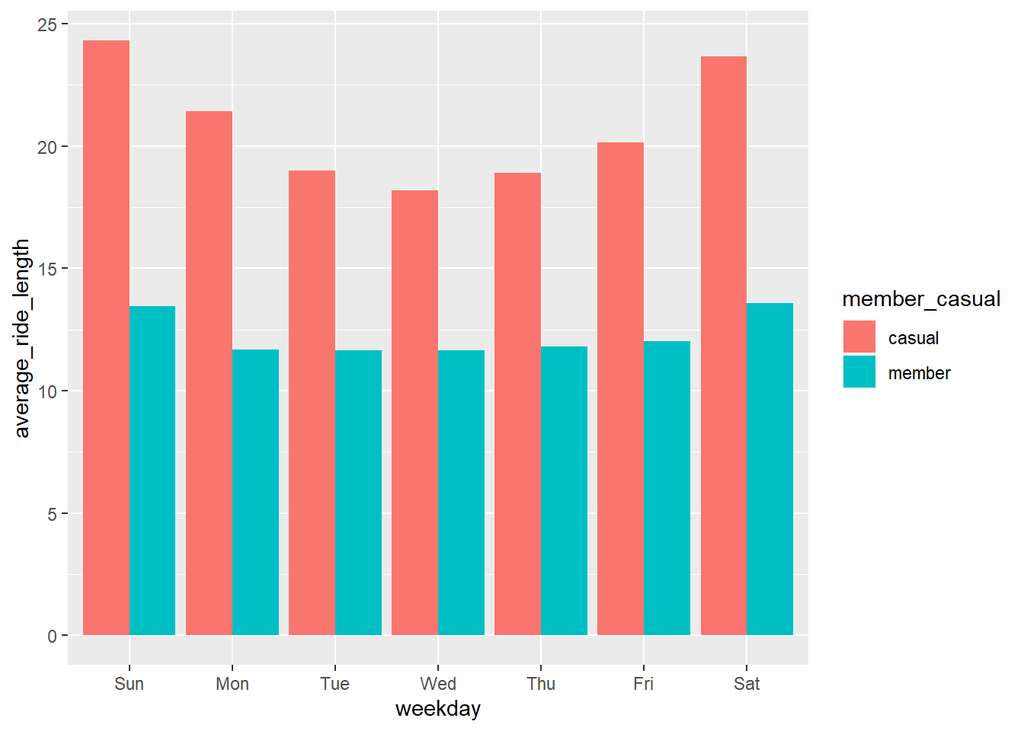

```r
cyclistic_df2 %>%
  mutate(weekday = wday(start_date, label = TRUE)) %>%
  group_by(member_casual, weekday) %>%
  summarise(number_of_rides = n(), average_ride_length = mean(ride_length)) %>%
  arrange(member_casual, weekday) %>%
  ggplot(aes(x = weekday, y = average_ride_length, fill = member_casual)) +
  geom_col(position = "dodge")
```

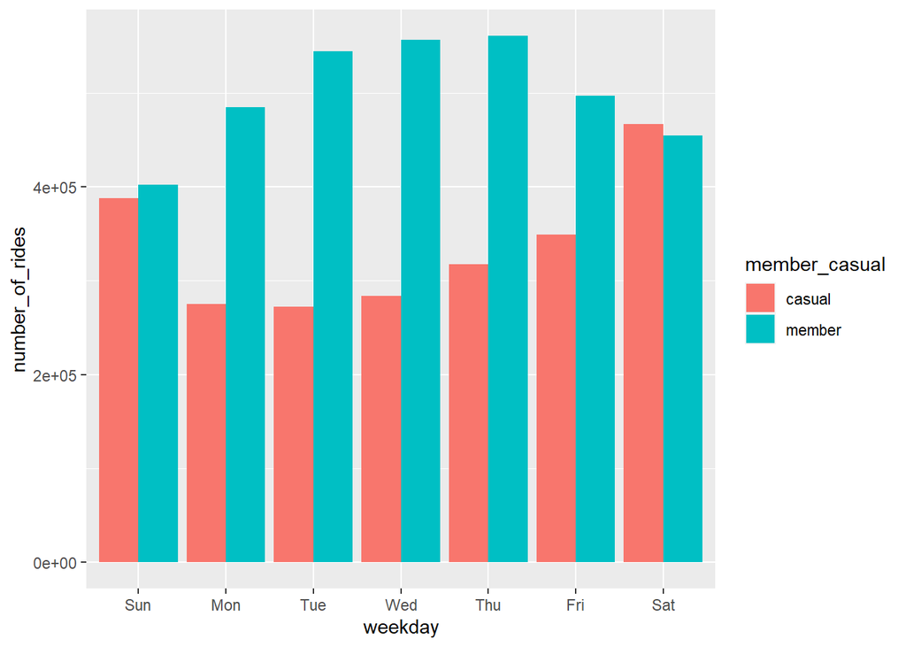

```r
cyclistic_df2 %>%
  mutate(weekday = wday(start_date, label = TRUE)) %>%
  group_by(member_casual, weekday) %>%
  summarise(number_of_rides = n(), average_ride_length = mean(ride_length)) %>%
  arrange(member_casual, weekday) %>%
  ggplot(aes(x = weekday, y = number_of_rides, fill = member_casual)) +
  geom_col(position = "dodge")
```

```r
cyclistic_df2 %>%
  group_by(member_casual, month) %>%
  summarise(number_of_rides = n(), average_ride_length = mean(ride_length)) %>%
  arrange(member_casual, month)
```

```
## # A tibble: 24 × 4
## # Groups:   member_casual [2]
##    member_casual month number_of_rides average_ride_length
##    <chr>         <chr>           <int>               <dbl>
##  1 casual        01              39905                13.5
##  2 casual        02              42922                15.9
##  3 casual        03              62049                15.1
##  4 casual        04             146893                20.3
##  5 casual        05             279764                25.4
##  6 casual        06             368082                23.3
##  7 casual        07             405179                23.1
##  8 casual        08             358161                21.4
##  9 casual        09             296074                19.9
## 10 casual        10             208611                18.4
## # ℹ 14 more rows
```

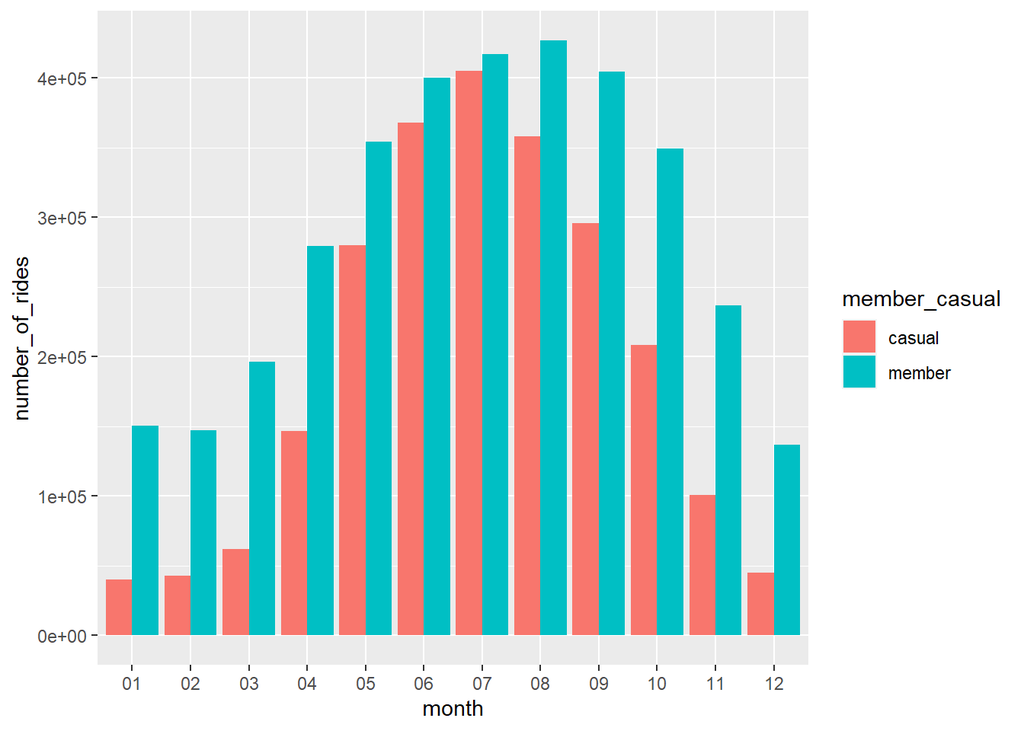

```r
cyclistic_df2 %>%
  group_by(member_casual, month) %>%
  summarise(number_of_rides = n(), average_ride_length = mean(ride_length)) %>%
  arrange(member_casual, month) %>%
  ggplot(aes(x = month, y = number_of_rides, fill = member_casual))+
  geom_col(position = "dodge")
```

```r
cyclistic_df2 %>%
  group_by(day_of_week, rideable_type) %>%
  summarise(number_of_rides = n()) %>%
  arrange(day_of_week, rideable_type)
```

```
## # A tibble: 21 × 3
## # Groups:   day_of_week [7]
##    day_of_week rideable_type number_of_rides
##    <chr>       <chr>                   <int>
##  1 Friday      classic_bike           369525
##  2 Friday      docked_bike             23163
##  3 Friday      electric_bike          453988
##  4 Monday      classic_bike           349076
##  5 Monday      docked_bike             20864
##  6 Monday      electric_bike          389668
##  7 Saturday    classic_bike           416990
##  8 Saturday    docked_bike             37604
##  9 Saturday    electric_bike          466519
## 10 Sunday      classic_bike           361099
## # ℹ 11 more rows
```

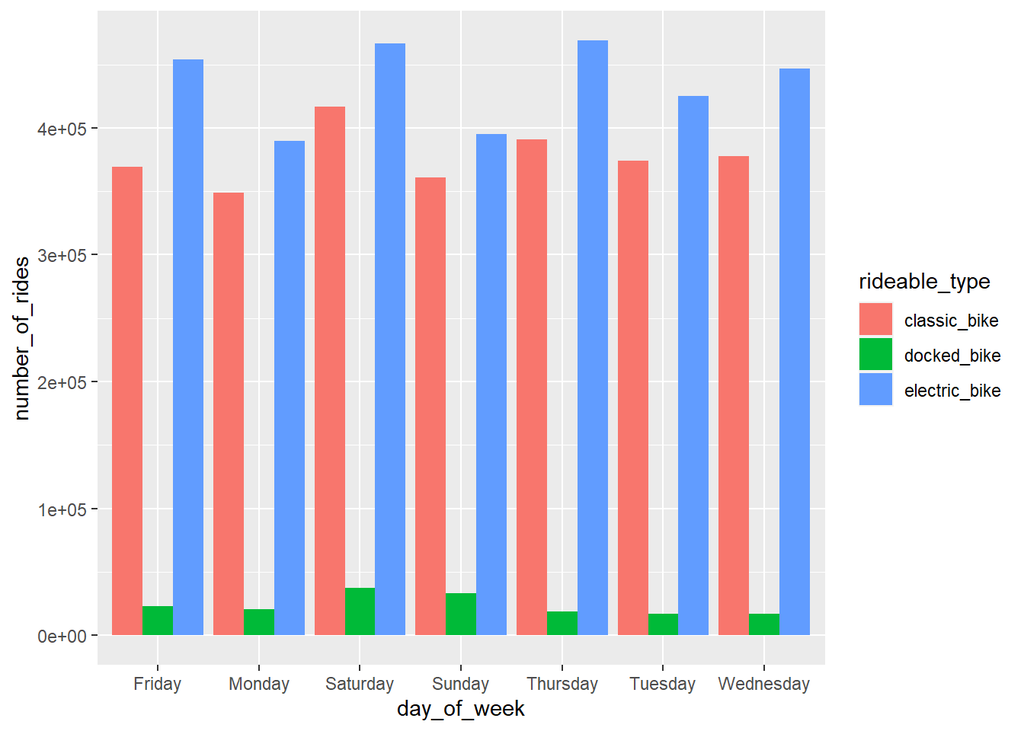

```r
cyclistic_df2 %>%
  group_by(day_of_week, rideable_type) %>%
  summarise(number_of_rides = n()) %>%
  arrange(day_of_week, rideable_type) %>%
  ggplot(aes(x = day_of_week, y = number_of_rides, fill = rideable_type))+
  geom_col(position = "dodge")
```

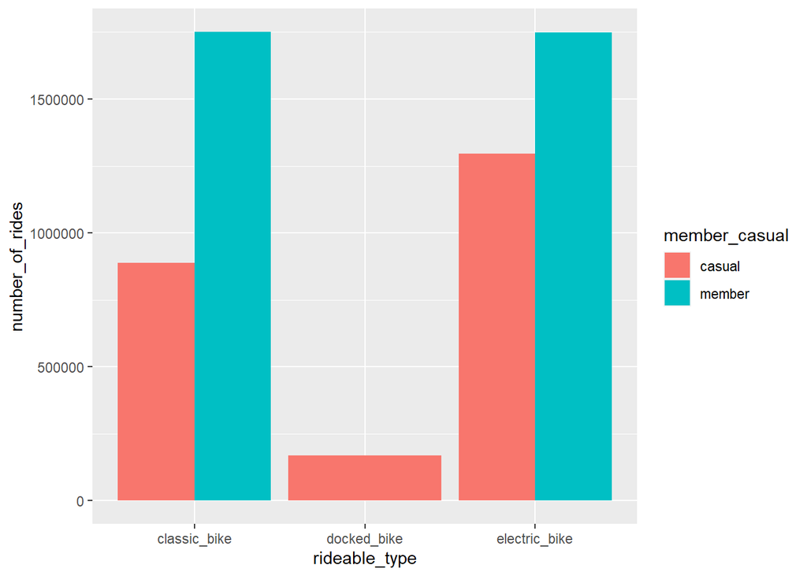

```r
cyclistic_df2 %>%
  group_by(rideable_type, member_casual) %>%
  summarise(number_of_rides = n()) %>%
  arrange(rideable_type, member_casual) %>%
  ggplot(aes(x = rideable_type, y = number_of_rides, fill = member_casual))+
  geom_col(position = "dodge")
```

## Act

The final phase is the act phase where I must come up with my top three recommendations for the company based on my analysis.

1. Offer membership plan for weekends called Weekend Warriors where it is a specific “weekend only” type. This could convert the large casual users into members if the price is lower and they only use the bikes on the weekends mostly.
2. Offer a summer membership as both tourists and locals seem to utilize the service mostly during these months. This will incentivize casual members to consider becoming members as it will only be during the months with better weather and those who come for trips.
3. Offer a new membership for the year where members pay full price for May through October and a discounted price for November through April. As there is a great decline during winter months perhaps if the service was discounted more people who live in the city can also be converted into members who use the service as a means of transportation to and from work.